# Practical Machine Learning Course Project

Nick Chia

04/06/2020

# Overview

## Background

Using devices such as Jawbone Up, Nike FuelBand, and Fitbit it is now possible to collect a large amount of data about personal activity relatively inexpensively. These type of devices are part of the quantified self movement – a group of enthusiasts who take measurements about themselves regularly to improve their health, to find patterns in their behavior, or because they are tech geeks. One thing that people regularly do is quantify how much of a particular activity they do, but they rarely quantify how well they do it. In this project, your goal will be to use data from accelerometers on the belt, forearm, arm, and dumbell of 6 participants. They were asked to perform barbell lifts correctly and incorrectly in 5 different ways. More information is available from the website here: http://web.archive.org/web/20161224072740/http:/groupware.les.inf.puc-rio.br/har (see the section on the Weight Lifting Exercise Dataset).

## Data

The training data for this project are available here:

https://d396qusza40orc.cloudfront.net/predmachlearn/pml-training.csv

The test data are available here:

https://d396qusza40orc.cloudfront.net/predmachlearn/pml-testing.csv

The data for this project come from this source: http://web.archive.org/web/20161224072740/http:/groupware.les.inf.puc-rio.br/har. If you use the document you create for this class for any purpose please cite them as they have been very generous in allowing their data to be used for this kind of assignment.

## Project Goal

The goal of your project is to predict the manner in which they did the exercise. This is the “classe” variable in the training set. You may use any of the other variables to predict with. You should create a report describing how you built your model, how you used cross validation, what you think the expected out of sample error is, and why you made the choices you did. You will also use your prediction model to predict 20 different test cases.

# Load Require Packages

```r
# Load the necessary packages
library(caret)
library(rattle)
library(randomForest)
library(gbm)
library(parallel)
library(doParallel)
```

# Loading and Cleaning the Data

```r
# Set the URl for each dataset
trainURL <- "https://d396qusza40orc.cloudfront.net/predmachlearn/pml-training.csv"
testURL <- "https://d396qusza40orc.cloudfront.net/predmachlearn/pml-testing.csv"

# Download the data
training <- read.csv(url(trainURL))
test <- read.csv(url(testURL))

# Split the training set
inTrain <- createDataPartition(training$classe, p = 0.6, list = FALSE)
trainingSet <- training[inTrain,]
validationSet <- training[-inTrain,]
dim(trainingSet);dim(validationSet)
```

```
## [1] 11776   160
```

```
## [1] 7846  160
```

```r
# Remove variables have a very low variance
NZV <- nearZeroVar(trainingSet)
trainingSet <- trainingSet[, -NZV]
validationSet <- validationSet[, -NZV]
dim(trainingSet);dim(validationSet)
```

```
## [1] 11776   106
```

```
## [1] 7846  106
```

```r
# Remove variables that largely contain "NA"
NAvar <- sapply(trainingSet, function(x) mean(is.na(x))) > 0.7
trainingSet <- trainingSet[, NAvar == FALSE]
validationSet <- validationSet[, NAvar == FALSE]
dim(trainingSet);dim(validationSet)
```

```
## [1] 11776    59
```

```
## [1] 7846   59
```

```r
# Remove variables that are irrelevant for prediction in columns 1-5
trainingSet <- trainingSet[, -(1:5)]
validationSet <- validationSet[, -(1:5)]
dim(trainingSet);dim(validationSet)
```

```
## [1] 11776    54
```

```
## [1] 7846   54
```

# Building Predictive Models

We will build three models: A classification tree, random forest model and gradient boosting machine model.

## Decision Tree

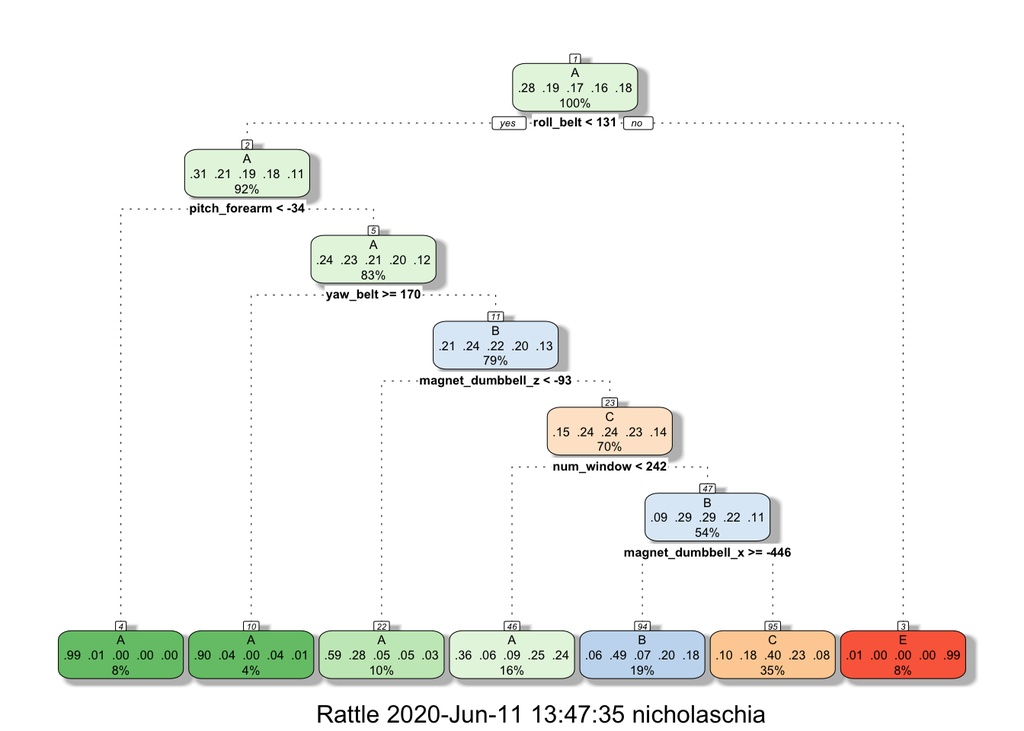

```r
set.seed(5)
modFitDT <- train(classe ~ ., method = "rpart", data = trainingSet)
fancyRpartPlot(modFitDT$finalModel)
```

The classification tree model will predict on the validation set.

```r
predictDT <- predict(modFitDT, newdata = validationSet)
confMatDT <- confusionMatrix(predictDT, validationSet$classe)
confMatDT
```

```
## Confusion Matrix and Statistics
##
##           Reference
## Prediction    A    B    C    D    E
##          A 1786  293  151  356  298
##          B  107  717  117  300  268
##          C  334  508 1100  630  206
##          D    0    0    0    0    0
##          E    5    0    0    0  670
##
## Overall Statistics
##
##                Accuracy : 0.5446
##                  95% CI : (0.5335, 0.5557)
##     No Information Rate : 0.2845
##     P-Value [Acc > NIR] : < 2.2e-16
##
##                   Kappa : 0.4167
##
##  Mcnemar's Test P-Value : NA
##
## Statistics by Class:
##
##                      Class: A Class: B Class: C Class: D Class: E
## Sensitivity            0.8002  0.47233   0.8041   0.0000  0.46463
## Specificity            0.8044  0.87484   0.7410   1.0000  0.99922
## Pos Pred Value         0.6193  0.47515   0.3960      NaN  0.99259
## Neg Pred Value         0.9101  0.87360   0.9471   0.8361  0.89234
## Prevalence             0.2845  0.19347   0.1744   0.1639  0.18379
## Detection Rate         0.2276  0.09138   0.1402   0.0000  0.08539
## Detection Prevalence   0.3676  0.19233   0.3541   0.0000  0.08603
## Balanced Accuracy      0.8023  0.67359   0.7725   0.5000  0.73193
```

## Random Forest

```r
cluster <- makeCluster(detectCores() - 1)
registerDoParallel(cluster)

set.seed(5)
fitCtrl <- trainControl(method = "cv", number = 3, verboseIter = FALSE, allowParallel = TRUE)
modFitRF <- train(classe ~ ., data = trainingSet, method = "rf", trControl = fitCtrl)

stopCluster(cluster)
registerDoSEQ()
```

Now, the model will be tested on our validation set.

```r
predictRF <- predict(modFitRF, newdata = validationSet)
confMatRF <- confusionMatrix(predictRF, validationSet$classe)
confMatRF
```

```
## Confusion Matrix and Statistics
##
##           Reference
## Prediction    A    B    C    D    E
##          A 2231    9    0    0    0
##          B    0 1507    5    0    0
##          C    0    1 1363    4    0
##          D    0    1    0 1282    1
##          E    1    0    0    0 1441
##
## Overall Statistics
##
##                Accuracy : 0.9972
##                  95% CI : (0.9958, 0.9982)
##     No Information Rate : 0.2845
##     P-Value [Acc > NIR] : < 2.2e-16
##
##                   Kappa : 0.9965
##
##  Mcnemar's Test P-Value : NA
##
## Statistics by Class:
##
##                      Class: A Class: B Class: C Class: D Class: E
## Sensitivity            0.9996   0.9928   0.9963   0.9969   0.9993
## Specificity            0.9984   0.9992   0.9992   0.9997   0.9998
## Pos Pred Value         0.9960   0.9967   0.9963   0.9984   0.9993
## Neg Pred Value         0.9998   0.9983   0.9992   0.9994   0.9998
## Prevalence             0.2845   0.1935   0.1744   0.1639   0.1838
## Detection Rate         0.2843   0.1921   0.1737   0.1634   0.1837
## Detection Prevalence   0.2855   0.1927   0.1744   0.1637   0.1838
## Balanced Accuracy      0.9990   0.9960   0.9978   0.9983   0.9996
```

## Gradient Boosting Machine

```r
set.seed(5)
fitCtrl2 <- trainControl(method = "repeatedcv", number = 3, repeats = 1)
modFitGBM <- train(classe ~ ., data = trainingSet, method = "gbm", trControl = fitCtrl2, verbose = FALSE)
modFitGBM$finalModel
```

```
## A gradient boosted model with multinomial loss function.
## 150 iterations were performed.
## There were 53 predictors of which 52 had non-zero influence.
```

The model is then tested on the validation set.

```r
predictGBM <- predict(modFitGBM, newdata = validationSet)
confMatGBM <- confusionMatrix(predictGBM, validationSet$classe)
confMatGBM
```

```
## Confusion Matrix and Statistics
##
##           Reference
## Prediction    A    B    C    D    E
##          A 2219   18    0    0    0
##          B   12 1492   14    5    9
##          C    0    7 1351   17    4
##          D    1    1    3 1263   13
##          E    0    0    0    1 1416
##
## Overall Statistics
##
##                Accuracy : 0.9866
##                  95% CI : (0.9838, 0.989)
##     No Information Rate : 0.2845
##     P-Value [Acc > NIR] : < 2.2e-16
##
##                   Kappa : 0.9831
##
##  Mcnemar's Test P-Value : NA
##
## Statistics by Class:
##
##                      Class: A Class: B Class: C Class: D Class: E
## Sensitivity            0.9942   0.9829   0.9876   0.9821   0.9820
## Specificity            0.9968   0.9937   0.9957   0.9973   0.9998
## Pos Pred Value         0.9920   0.9739   0.9797   0.9859   0.9993
## Neg Pred Value         0.9977   0.9959   0.9974   0.9965   0.9960
## Prevalence             0.2845   0.1935   0.1744   0.1639   0.1838
## Detection Rate         0.2828   0.1902   0.1722   0.1610   0.1805
## Detection Prevalence   0.2851   0.1953   0.1758   0.1633   0.1806
## Balanced Accuracy      0.9955   0.9883   0.9916   0.9897   0.9909
```

# Selecting and Testing the Model

From the prediction accuracy of each model that was predicted on the validation set, the best performing model was the random forest model. Therefore, we will use this model for predicting on the test set.

```r
predictFinal <- predict(modFitRF, newdata = test)
predictFinal
```

```
##  [1] B A B A A E D B A A B C B A E E A B B B
## Levels: A B C D E
```